# Relatório Caso Prático

Análise Exploratória de dados

11-12-2025

[figure not shown]

# Introdução

O presente relatório insere-se no Âmbito da Unidade Curricular de **Análise Exploratória de dados**. O objetivo deste trabalho é analisar os dados do *European Values Study*, comparando atitudes e valores entre Portugal e Finlândia. Para a realização deste estudo, foi utilizada uma base de dados composta por dois tipos de variáveis fundamentais:

- **Variáveis Sociodemográficas:** O país de residência (Portugal e Finlândia), o Género, o Ano de nasciemento (que permitiu criar a variável **“Gerações”**) e o Nível de educação
- **Variáveis de Opinião:** Questões focadas no capital social e confiança interpessoal, nomeadamente o grau de confiança na vizinhança e a confiança em pessoas conhecidas pessoalmente.

# Análise Descritiva

Neste tópico respondemos ás questões criadas antecipadamente para poder responder através dos dados. As mesmas vão ser respondidas e para tal vão ser usados gráficos.

## 2.1. Existe diferença no nível de confiança em pessoas da vizinhança entre países diferentes?

A primeira questão procura perceber se existem diferenças no sentimento de confiança na vizinhança entre os países.

| País | Frequência_Absoluta | Frequência_Relativa |
| --- | --- | --- |
| Finland | 1,198 | 49.67 |
| Portugal | 1,214 | 50.33 |

Nos primeiros resultados apresentados, podemos observar o número total de respostas de cada país. Tanto as frequências absolutas como as relativas indicam que Portugal e Finlândia têm um número equivalente de participantes, o que permite fazer comparações de forma equilibrada.

| Confiança_vizinhança | Frequência_Absoluta | Frequência_Relativa |
| --- | --- | --- |
| do not trust at all | 63 | 2.61 |
| do not trust very much | 303 | 12.56 |
| dont know | 22 | 0.91 |
| no answer | 5 | 0.21 |
| trust completely | 772 | 32.01 |
| trust somewhat | 1,247 | 51.70 |

A análise das respostas sobre confiança na vizinhança mostra um cenário predominantemente positivo. A grande maioria dos inquiridos afirma confiar nos seus vizinhos, seja **razoavelmente (51,7%)** ou **completamente (32,0%)**, o que representa **83,7% da amostra**. Em contraste, apenas **15,2%** revelam algum grau de desconfiança, divididos entre os que **não confiam muito (12,6%)** e os que **não confiam nada (2,6%)**. Os casos de indefinição ou ausência de resposta são residuais **(1,1%)**.

**LEGENDA:** -2: No answer -1: Dont know 1: Trust completely 2:trust somewhat 3: Do not trust very much 4: Do not trust at all

| País | -2 | -1 | 1 | 2 | 3 | 4 |
| --- | --- | --- | --- | --- | --- | --- |
| Finland | 0.33 | 0.83 | 44.82 | 46.91 | 6.26 | 0.83 |
| Portugal | 0.08 | 0.99 | 19.36 | 56.43 | 18.78 | 4.37 |

Este padrão evidencia uma forte presença de confiança interpessoal no contexto comunitário, sugerindo relações sociais estáveis e um ambiente de vizinhança marcado por coesão e segurança percebida.

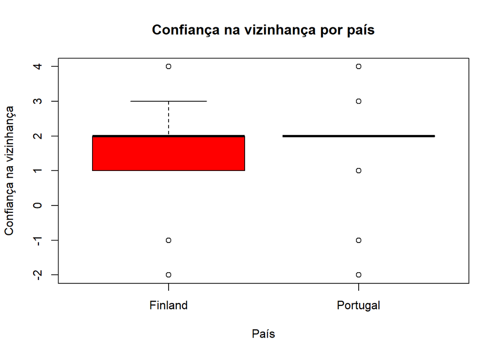

## 2.2. O ano de nascimento influencia o nível de educação dos inquiridos?

Neste tópico é abordada uma comparação entre o nível de educação dos inquiridos, dependendo do ano de nascimento. Para tornar a análise dos resultados mais fácil optámos por divir os anos de nascimento pelas geracões correspondentes

| Geracao | Frequência_Absoluta | Frequência_Relativa |
| --- | --- | --- |
| Baby Boomers | 949 | 42.77 |
| Gen X | 695 | 31.32 |
| Millennials | 556 | 25.06 |
| Gen Z | 19 | 0.86 |

A distribuição geracional evidencia uma predominância clara de grupos mais velhos, com menor representação das gerações mais jovens. Este padrão sugere que as experiências sociais e perceções recolhidas refletem maioritariamente trajetórias de vida mais longas e consolidadas.

| nível_de_educação | Frequência_Absoluta | Frequência_Relativa |
| --- | --- | --- |
| (Upper) secondary education | 635 | 26.44 |
| First stage of tertiary education | 681 | 28.35 |
| Lower secondary or second stage of basic education | 186 | 7.74 |
| Post-secondary non-tertiary education | 107 | 4.45 |
| Pre-primary education or none | 64 | 2.66 |
| Primary education or first stage of basic education | 705 | 29.35 |
| Second stage of tertiary education | 24 | 1.00 |

A análise do nível de educação revela uma predominância de formações básicas (apesar de haver pouca frequência em pessoas com ensino pré-primário ou sem ensino) e intermédias, com destaque para o ensino primário, secundário e primeira etapa do ensino superior. Por contraste, os níveis mais avançados de escolaridade, como o mestrado (segunda etapa do ensino superior), estão pouco representados, sendo residual na amostra. Esta composição sugere que, apesar da presença de formação superior, não podemos descartar os outros com valores menos elevados (pessoas com ensino pré-primário ou sem ensino e também a segunda etapa do ensino superior), já que os mesmos por mais baixos que sejam vão sempre influenciar os estudos.

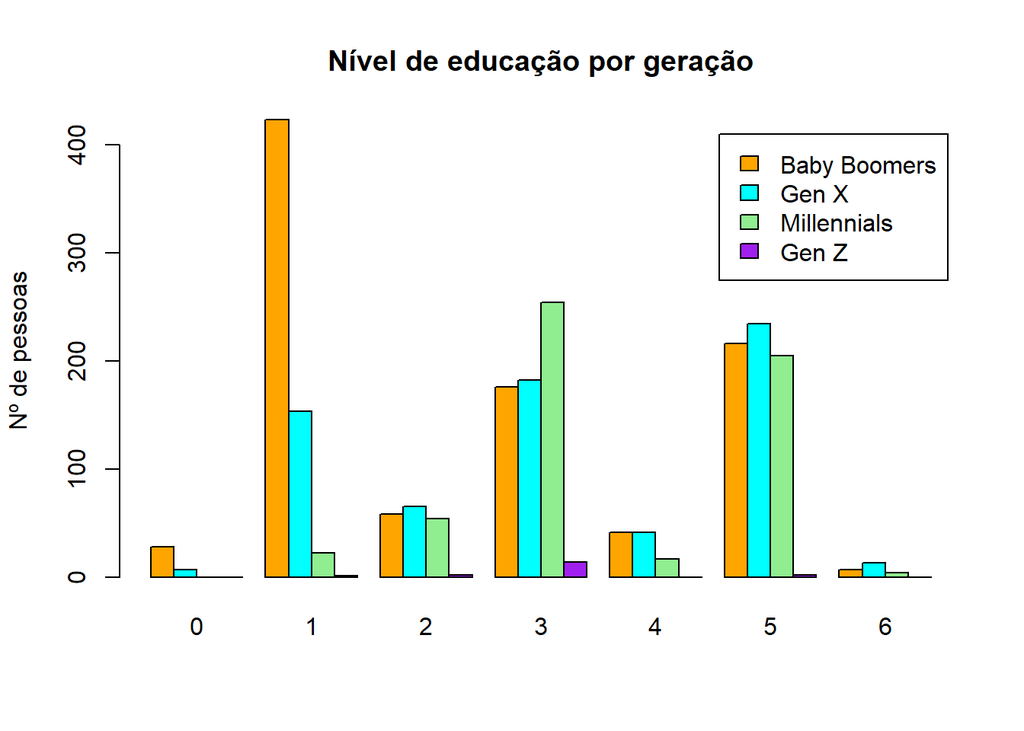

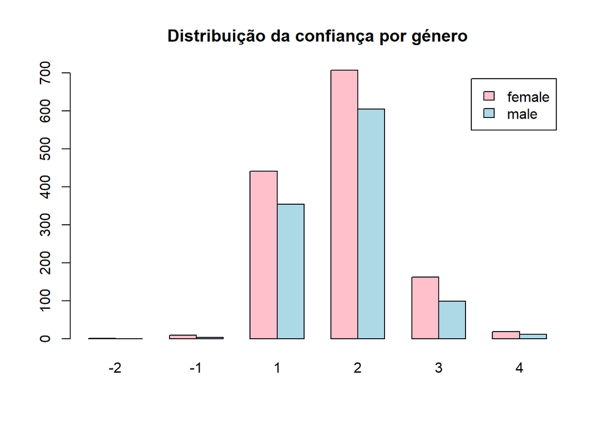